# Module2_Project

### Checking performance on test data

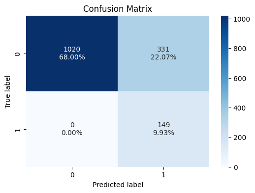

```python
# Generate and visualize the confusion matrix for the best (tuned) model on the test data
# This evaluates how well the model performs on unseen (test) data

confusion_matrix_sklearn(estimator, X_test, y_test)
```

- Perfect Recall: The model correctly identified all actual loan acceptors (True Positives = 149, False Negatives = 0).
- High False Positives: A significant number of false positives (331) indicates that the model over-predicts loan acceptance.
- No False Negatives: Ensures no potential loan customer was missed, aligning with the business goal.

```python
# Evaluate the performance of the best (tuned) Decision Tree model on the test data
# This will give key classification metrics like Accuracy, Recall, Precision, and F1-score

decision_tree_tune_perf_test = model_performance_classification_sklearn(estimator, X_test, y_test)

# Display the resulting performance metrics DataFrame for the test set
decision_tree_tune_perf_test
```

|  | Accuracy | Recall | Precision | F1 |
| --- | --- | --- | --- | --- |
| 0 | 0.779333 | 1.0 | 0.310417 | 0.473768 |

- Recall = 1.0: The model successfully captured all actual loan acceptors , ensuring no missed opportunities.
- Precision = 0.31: While recall is perfect, precision is relatively low due to a high number of false positives.
- Accuracy = ~78%: Overall correctness is reasonable but slightly lower than expected given the imbalanced dataset.
- F1-score = ~47%: Balances recall and precision, indicating moderate performance.
- Perfect Recall: The model ensures no potential loan customer is overlooked, which is crucial for maximizing revenue opportunities.
- Focus on Recall: This aligns with the business objective of minimizing false negatives to maximize loan acceptance rates.
- High False Positives: The model over-predicts loan acceptance, leading to inefficiencies in marketing efforts.
- Overfitting Concern: Perfect recall on test data suggests some degree of overfitting, which may not generalize well to unseen data.

### Post-pruning

```python
# Initialize a base Decision Tree Classifier with a fixed random state for reproducibility
clf = DecisionTreeClassifier(random_state=1)

# Compute the pruning path using cost-complexity pruning
# This gives us a sequence of 'ccp_alpha' values and corresponding total impurity of leaves
path = clf.cost_complexity_pruning_path(X_train, y_train)

# Extract the effective alphas and corresponding impurities from the pruning path
ccp_alphas, impurities = path.ccp_alphas, path.impurities
```

```python
# Convert the pruning path data (ccp_alphas and impurities) into a pandas DataFrame
# This allows for easier inspection and analysis of the cost-complexity pruning path

pd.DataFrame(path)
```

|  | ccp_alphas | impurities |
| --- | --- | --- |
| 0 | 0.000000 | 0.000000 |
| 1 | 0.000223 | 0.001114 |
| 2 | 0.000250 | 0.001614 |
| 3 | 0.000268 | 0.002688 |
| 4 | 0.000272 | 0.003232 |
| 5 | 0.000273 | 0.004868 |
| 6 | 0.000276 | 0.005420 |
| 7 | 0.000381 | 0.005801 |
| 8 | 0.000527 | 0.006329 |
| 9 | 0.000625 | 0.006954 |
| 10 | 0.000700 | 0.007654 |
| 11 | 0.000769 | 0.010731 |
| 12 | 0.000882 | 0.014260 |
| 13 | 0.000889 | 0.015149 |
| 14 | 0.001026 | 0.017200 |
| 15 | 0.001305 | 0.018505 |
| 16 | 0.001647 | 0.020153 |
| 17 | 0.002333 | 0.022486 |
| 18 | 0.002407 | 0.024893 |
| 19 | 0.003294 | 0.028187 |
| 20 | 0.006473 | 0.034659 |
| 21 | 0.025146 | 0.084951 |
| 22 | 0.039216 | 0.124167 |
| 23 | 0.047088 | 0.171255 |

1. Overfitting Concern:
- The initial tree (at ccp_alpha = 0) has very low impurity, suggesting overfitting to the training data.
- Post-pruning will help reduce overfitting by simplifying the tree.
2. Balancing Complexity and Impurity:
- Choosing an appropriate ccp_alpha value is crucial to balance model complexity and impurity.
- A higher ccp_alpha leads to simpler trees but may increase impurity, while a lower ccp_alpha keeps the tree complex but risks overfitting.
3. Cost-Complexity Trade-off:
- The pruning path illustrates the trade-off between the cost of adding splits (complexity) and the reduction in impurity.
- Selecting the right ccp_alpha ensures the model is neither too simple nor too complex.

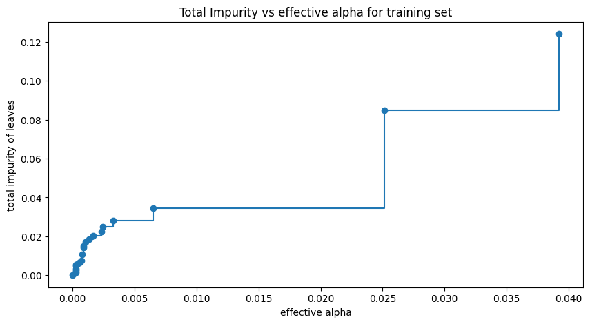

```python
# Create a figure and axis for plotting with a specified size
fig, ax = plt.subplots(figsize=(10, 5))

# Plot effective alpha values vs total impurity of leaves
# Using steps-post drawstyle to emphasize discrete changes between alphas
# Exclude the last alpha (ccp_alphas[-1]) since it collapses the tree to a single node
ax.plot(ccp_alphas[:-1], impurities[:-1], marker="o", drawstyle="steps-post")

# Label the x-axis
ax.set_xlabel("effective alpha")

# Label the y-axis
ax.set_ylabel("total impurity of leaves")

# Set the title of the plot
ax.set_title("Total Impurity vs effective alpha for training set")

# Display the plot
plt.show()
```